# Project Business Statistics: E-news Express

#### Time spent on old page

```python
df_old = df[df['landing_page'] == 'old'] #Subset dataframe to consist of records for the old page; assign to variable
df_old.head() #view first five rows of the dataframe
```

|  | user_id | group | landing_page | time_spent_on_the_page | converted | language_preferred |
| --- | --- | --- | --- | --- | --- | --- |
| 0 | 546592 | control | old | 3.48 | no | Spanish |
| 3 | 546567 | control | old | 3.02 | no | French |
| 5 | 546558 | control | old | 5.28 | yes | English |
| 7 | 546581 | control | old | 6.53 | yes | Spanish |
| 9 | 546548 | control | old | 2.08 | no | English |

```python
df_old.tail() #Check last five rows of the dataframe
```

|  | user_id | group | landing_page | time_spent_on_the_page | converted | language_preferred |
| --- | --- | --- | --- | --- | --- | --- |
| 85 | 546564 | control | old | 0.91 | no | French |
| 89 | 546561 | control | old | 6.04 | yes | French |
| 92 | 546566 | control | old | 8.35 | no | French |
| 94 | 546550 | control | old | 3.05 | no | English |
| 96 | 546544 | control | old | 6.52 | yes | English |

```python
df_old.shape #number of rows and columns in the subsetted dataset
```

```
(50, 6)
```

```python
df_old.describe() #Check statistical summary of subset dataframe
```

|  | user_id | time_spent_on_the_page |
| --- | --- | --- |
| count | 50.00000 | 50.000000 |
| mean | 546566.50000 | 4.532400 |
| std | 17.67767 | 2.581975 |
| min | 546493.00000 | 0.190000 |
| 25% | 546555.25000 | 2.720000 |
| 50% | 546567.50000 | 4.380000 |
| 75% | 546579.75000 | 6.442500 |
| max | 546592.00000 | 10.300000 |

```python
print('The least amount of time spent on the page is', df_old['time_spent_on_the_page'].min(), 'minutes.') #print the least value in the column

print('The most amount of time spent on the page is', df_old['time_spent_on_the_page'].max(), 'minutes.') #print the greatest value in the column

print('The median value in the column is', round(df_old['time_spent_on_the_page'].median(),2), 'minutes.') #print the median value in the column

print('The average value of the column is', round(df_old['time_spent_on_the_page'].mean(),2), 'minutes.') #print the average value in the column
```

```
The least amount of time spent on the page is 0.19 minutes.
The most amount of time spent on the page is 10.3 minutes.
The median value in the column is 4.38 minutes.
The average value of the column is 4.53 minutes.
```

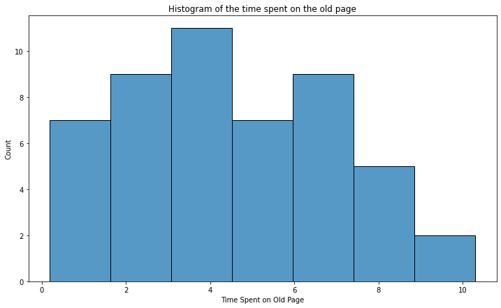

```python
plt.figure(figsize=(12,7)); #display the graph with the given size specifiations for the x-axis and y-axis respectively.
sns.histplot(data = df, x = df_old['time_spent_on_the_page']); #Create a histogram for the values in the column.
plt.xlabel('Time Spent on Old Page'); #display title in bracket as x-axis label
plt.title('Histogram of the time spent on the old page'); #insert title of the graph
```

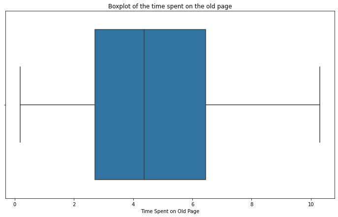

```python
plt.figure(figsize=(12,7)); #display the graph with the given size specifiations for the x-axis and y-axis respectively.
sns.boxplot(data = df, x = df_old['time_spent_on_the_page']); #Create a boxplot for the values in this column.
plt.xlabel('Time Spent on Old Page'); #display title in bracket as x-axis label
plt.title('Boxplot of the time spent on the old page'); #insert title of the graph
```

Observation:

- The distribution for this subset is slightly right skewed though not very significant.
- There are no outliers in the distribution illustrating there was no 'extraordinary' amount of time spent by users on the old page.
- The least and greatest amount of time spent on the old page is 0.19 minutes (11.4 seconds) and 10.3 minutes respectively.
- 25% of users spent almost 3 minutes on the old page and 75% of users spent at most 6.5 minutes.

#### Time spent on new page

```python
df_new = df[df['landing_page'] == 'new'] #Subset dataframe to consist of records for the new page; assign to variable
df_new.head() #view first five rows of the dataframe
```

|  | user_id | group | landing_page | time_spent_on_the_page | converted | language_preferred |
| --- | --- | --- | --- | --- | --- | --- |
| 1 | 546468 | treatment | new | 7.13 | yes | English |
| 2 | 546462 | treatment | new | 4.40 | no | Spanish |
| 4 | 546459 | treatment | new | 4.75 | yes | Spanish |
| 6 | 546448 | treatment | new | 5.25 | yes | French |
| 8 | 546461 | treatment | new | 10.71 | yes | French |

```python
df_new.tail() #view last five rows of the dataframe
```

|  | user_id | group | landing_page | time_spent_on_the_page | converted | language_preferred |
| --- | --- | --- | --- | --- | --- | --- |
| 93 | 546474 | treatment | new | 4.94 | no | French |
| 95 | 546446 | treatment | new | 5.15 | no | Spanish |
| 97 | 546472 | treatment | new | 7.07 | yes | Spanish |
| 98 | 546481 | treatment | new | 6.20 | yes | Spanish |
| 99 | 546483 | treatment | new | 5.86 | yes | English |

```python
df_new.shape #number of rows and column in this subsetted dataset
```

```
(50, 6)
```

```python
df_new.describe() #Check statistical summary of subset dataframe
```

|  | user_id | time_spent_on_the_page |
| --- | --- | --- |
| count | 50.00000 | 50.000000 |
| mean | 546467.50000 | 6.223200 |
| std | 14.57738 | 1.817031 |
| min | 546443.00000 | 1.650000 |
| 25% | 546455.25000 | 5.175000 |
| 50% | 546467.50000 | 6.105000 |
| 75% | 546479.75000 | 7.160000 |
| max | 546492.00000 | 10.710000 |

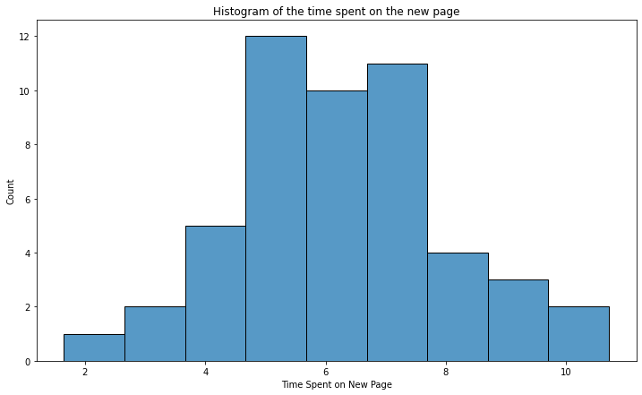

```python
plt.figure(figsize=(12,7)); #display the graph with the given size specifiations for the x-axis and y-axis respectively.
sns.histplot(data = df, x = df_new['time_spent_on_the_page']); #Create a histogram for the values in the column.
plt.xlabel('Time Spent on New Page'); #display title in bracket as x-axis label
plt.title('Histogram of the time spent on the new page'); #insert title of the graph
```

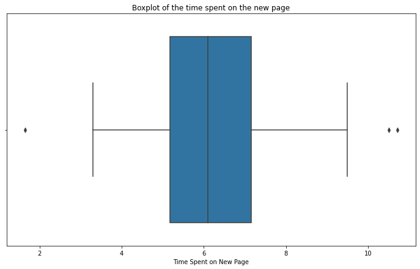

```python
plt.figure(figsize=(12,7)); #display the graph with the given size specifiations for the x-axis and y-axis respectively.
sns.boxplot(data = df, x = df_new['time_spent_on_the_page']); #Create a boxplot for the values in this column.
plt.xlabel('Time Spent on New Page'); #display title in bracket as x-axis label
plt.title('Boxplot of the time spent on the new page'); #insert title of the graph
```

Observation:

#### CONVERTED

```python
df['converted'].value_counts() #show the frequency of each value in the column.
```

```
yes    54
no     46
Name: converted, dtype: int64
```

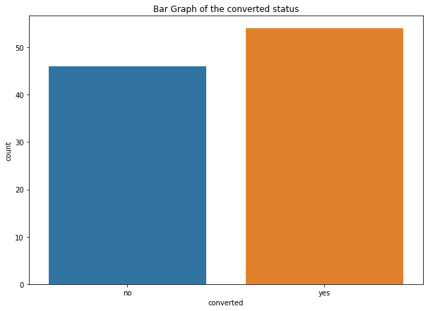

```python
plt.figure(figsize=(10,7)); #display the graph with the given size specifiations for the x-axis and y-axis respectively.
sns.countplot(data = df, x = 'converted'); #show bar graph of values in this column
plt.title('Bar Graph of the converted status'); #insert title of the graph
```

Observation:

- There are two groups in this column- no and yes.
- 'Yes' values consists 54% of the column while 'no' column consists 46% of values in the column generally denoting that there were more users that subscribed than those who did not.

#### LANGUAGE PREFERRED

```python
df['language_preferred'].unique() #show unique values in this column.
```

```
array(['Spanish', 'English', 'French'], dtype=object)
```

```python
df['language_preferred'].value_counts() #show the frequency of each value in the column.
```

```
Spanish    34
French     34
English    32
Name: language_preferred, dtype: int64
```

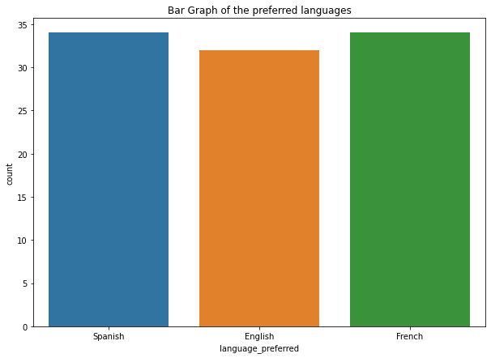

```python
plt.figure(figsize=(10,7)); #display the graph with the given size specifiations for the x-axis and y-axis respectively.
sns.countplot(data = df, x = 'language_preferred'); #show bar graph of values in this column
plt.title('Bar Graph of the preferred languages'); #insert title of the graph
```

Observation:

- There are 3 unique languages the website uses namely Spanish, English and French.
- Spanish and French are the most preferred languages but not too significantly preferred to English.

### Bivariate Analysis

#### Group vs Time spent on the page

```python
df_old['time_spent_on_the_page'].describe() #subset time spent on the page by the control group and give statistical summary
```

```
count    50.000000
mean      4.532400
std       2.581975
min       0.190000
25%       2.720000
50%       4.380000
75%       6.442500
max      10.300000
Name: time_spent_on_the_page, dtype: float64
```

```python
df_new['time_spent_on_the_page'].describe() ##subset time spent on the page by the treatment group and give statistical summary
```

```
count    50.000000
mean      6.223200
std       1.817031
min       1.650000
25%       5.175000
50%       6.105000
75%       7.160000
max      10.710000
Name: time_spent_on_the_page, dtype: float64
```

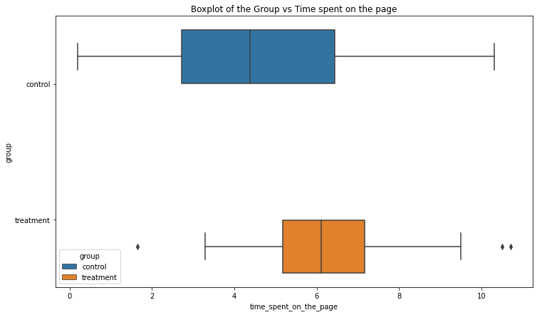

```python
plt.figure(figsize=(12,7)); #display the graph with the given size specifiations for the x-axis and y-axis respectively.
sns.boxplot(data = df, x = 'time_spent_on_the_page', y = 'group', hue = 'group'); #create boxplot for the two variables.
plt.title('Boxplot of the Group vs Time spent on the page'); #insert title of the graph
```

Observation:

- The distribution of the both groups are very slightly right skewed though almost insignificant.
- The distribution of the time spent by control group does not show any outliers compared to its counterpart which has outliers at both tails of its distribution.
- The minimum and maximum amount of time spent by the treatment group is higher than the control group due largely due to the presence of outliers.
- Also, the average amount of time spent by the treatment group is greater than the control group.
- In the control group, 25% of users spent almost 3 minutes on the page; 75% of users in this same group spent at most 6.4 minutes on the page.
- In the treatment group, 25% of users spent about 5.2 minutes on the page (significantly higher than the control group); 75% of users spent not more than 7.2 minutes.

#### Group vs Converted

```python
control_conv = df_old['converted'].value_counts() #number of users who subscribed in the control group
treat_conv = df_new['converted'].value_counts()
```

```python
print('The number of users who subscribed in the control group is', control_conv[1],'whilst the number of users who did not is', control_conv[0],'.')
print('The number of users who subscribed in the treatment group is', treat_conv[0],'whilst the number of users who did not is', treat_conv[1],'.')
```

```
The number of users who subscribed in the control group is 21 whilst the number of users who did not is 29 .
The number of users who subscribed in the treatment group is 33 whilst the number of users who did not is 17 .
```

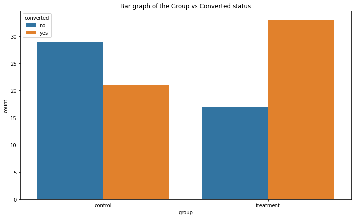

```python
plt.figure(figsize=(12,7)); #display the graph with the given size specifiations for the x-axis and y-axis respectively.
sns.countplot(data = df, hue = 'converted', x = 'group');
plt.title('Bar graph of the Group vs Converted status'); #insert title of the graph
```

Observation:

- The number of users who subscribed to the treatment group is significantly higher than those who did in the control group.

#### Group vs Language

```python
df_old['language_preferred'].value_counts() #frequencies of the different preferred languages in the control group
```

```
Spanish    17
French     17
English    16
Name: language_preferred, dtype: int64
```

```python
df_new['language_preferred'].value_counts() #frequencies of the different preferred languages in the control group
```

```
Spanish    17
French     17
English    16
Name: language_preferred, dtype: int64
```

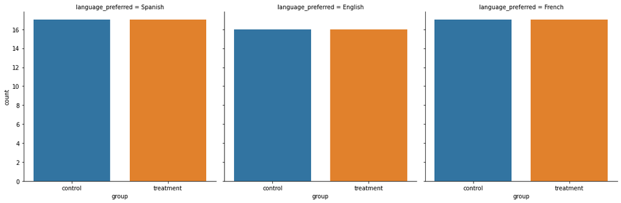

```python
plt.figure(figsize=(12,7)); #display the graph with the given size specifiations for the x-axis and y-axis respectively.
sns.catplot(data = df, x = 'group', col = 'language_preferred', kind = 'count');
```

Observation:

There is an even distribution of the three different languages in the control and treatment groups.

#### Converted vs Time spent on the page

```python
df[df['converted'] == 'yes']['time_spent_on_the_page'].describe()
```

```
count    54.000000
mean      6.623148
std       1.708427
min       2.580000
25%       5.500000
50%       6.495000
75%       7.367500
max      10.710000
Name: time_spent_on_the_page, dtype: float64
```

```python
df[df['converted'] == 'no']['time_spent_on_the_page'].describe()
```

```
count    46.000000
mean      3.915870
std       2.226897
min       0.190000
25%       2.337500
50%       3.980000
75%       4.922500
max       9.150000
Name: time_spent_on_the_page, dtype: float64
```

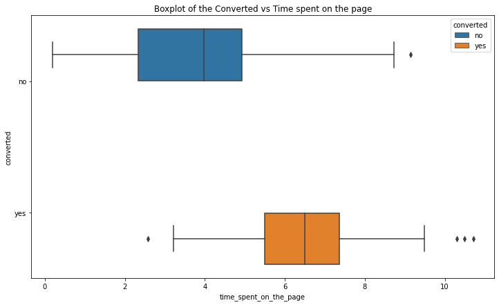

```python
plt.figure(figsize=(12,7)); #display the graph with the given size specifiations for the x-axis and y-axis respectively.
sns.boxplot(data = df, x = 'time_spent_on_the_page', y = 'converted', hue = 'converted'); #create boxplot for the two variables.
plt.title('Boxplot of the Converted vs Time spent on the page'); #insert title of the graph
```

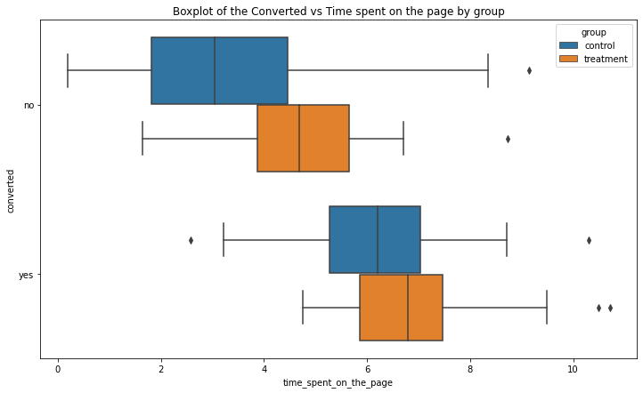

```python
#Multivariate visualization
plt.figure(figsize=(12,7)); #display the graph with the given size specifiations for the x-axis and y-axis respectively.
sns.boxplot(data = df, x = 'time_spent_on_the_page', y = 'converted', hue = 'group'); #create boxplot for the two variables.
plt.title('Boxplot of the Converted vs Time spent on the page by group'); #insert title of the graph
```

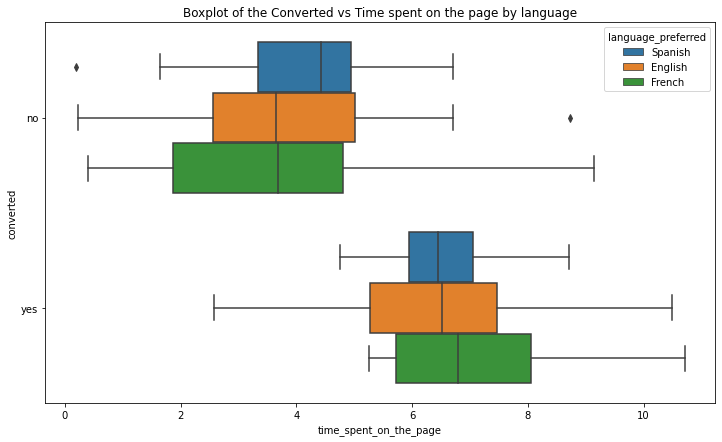

```python
#Multivariate visualization
plt.figure(figsize=(12,7)); #display the graph with the given size specifiations for the x-axis and y-axis respectively.
sns.boxplot(data = df, x = 'time_spent_on_the_page', y = 'converted', hue = 'language_preferred'); #create boxplot for the two variables.
plt.title('Boxplot of the Converted vs Time spent on the page by language'); #insert title of the graph
```

Observation:

#### Language vs Time spent on the page

```python
#statistical summary of overall time spent by spanish users.
df[df['language_preferred'] == 'Spanish']['time_spent_on_the_page'].describe()
```

```
count    34.000000
mean      5.331765
std       1.818095
min       0.190000
25%       4.475000
50%       5.605000
75%       6.515000
max       8.720000
Name: time_spent_on_the_page, dtype: float64
```

```python
#statistical summary of overall time spent by english users.
df[df['language_preferred'] == 'English']['time_spent_on_the_page'].describe()
```

```
count    32.000000
mean      5.559063
std       2.621079
min       0.220000
25%       3.617500
50%       5.755000
75%       7.137500
max      10.500000
Name: time_spent_on_the_page, dtype: float64
```

```python
#statistical summary of overall time spent by french users.
df[df['language_preferred'] == 'French']['time_spent_on_the_page'].describe()
```

```
count    34.000000
mean      5.253235
std       2.675413
min       0.400000
25%       3.395000
50%       5.315000
75%       7.367500
max      10.710000
Name: time_spent_on_the_page, dtype: float64
```

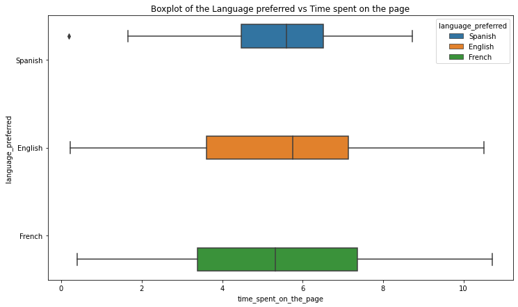

```python
plt.figure(figsize=(12,7)); #display the graph with the given size specifiations for the x-axis and y-axis respectively.
sns.boxplot(data = df, x = 'time_spent_on_the_page', y = 'language_preferred', hue = 'language_preferred'); #create boxplot for the two variables.
plt.title('Boxplot of the Language preferred vs Time spent on the page'); #insert title of the graph
```

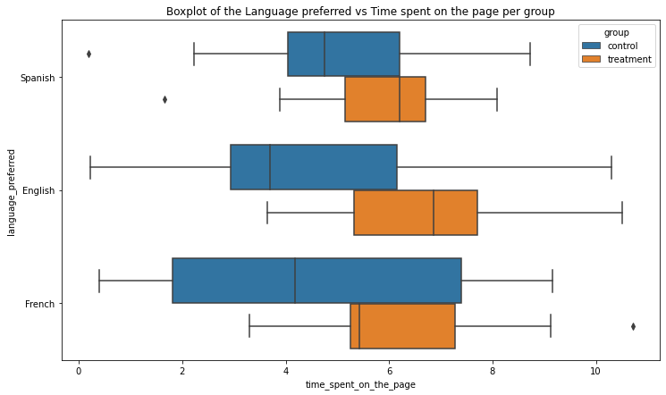

```python
#Multivariate visualization
plt.figure(figsize=(12,7)); #display the graph with the given size specifiations for the x-axis and y-axis respectively.
sns.boxplot(data = df, x = 'time_spent_on_the_page', y = 'language_preferred', hue = 'group'); #create boxplot for the two variables.
plt.title('Boxplot of the Language preferred vs Time spent on the page per group'); #insert title of the graph
```

Observation:

- The spanish and English distributions are left skewed while the French distribution is slightly right skewed.
- Only the Spanish distribution shows an outlier on the lower tail of its distribution.
- Spanish recorded the least amount of time spent on the page by a user whilst the french recorded the highest amount of time spent by a user.
- English has the highest mean time spent on the page whilst the French has the least.
- 25% of spanish users spent about 4.5 minutes, 3.6 minutes for English users and about 3.4 minutes for French users.
- 75% of spanish users spent about 6.5 minutes, 7.1 minutes for english users and about 7.4 minutes for french users.
- On the control page, spanish users had the highest mean time spent on the page.
- All 3 languages show a right skewed distribution.
- The maximum time recorded by a user on the control page was in the English group while the least amount of time spent on the page by a user was in the spanish group represented by the outlier in its distribution.
- The users of all the languages had greater mean time spent on the page compared to the control group hinting a general preference for the new page. This observation is highlighted further by the significant difference recorded in the minimum times they spent on the page.

#### Converted vs Language preferred

```python
df[df['converted'] == 'yes']['language_preferred'].value_counts()
```

```
English    21
Spanish    18
French     15
Name: language_preferred, dtype: int64
```

```python
df[df['converted'] == 'no']['language_preferred'].value_counts()
```

```
French     19
Spanish    16
English    11
Name: language_preferred, dtype: int64
```

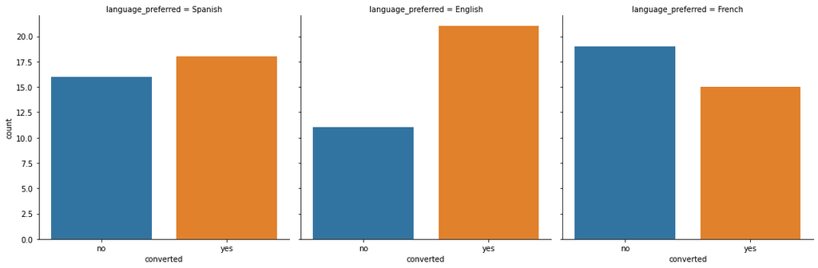

```python
plt.figure(figsize=(12,7)); #display the graph with the given size specifiations for the x-axis and y-axis respectively.
sns.catplot(data = df, x = 'converted', col = 'language_preferred', kind = 'count');
```

Observation:

- The english group had the most subscribers and was quite closely followed by the Spanish group.
- On the other hand, the french group recorded the highest number of non-subscribers which was closely followed by the spanish group.